# Clase 3: Gráficos :)

## Remover apenas una entrada de leyenda:

Aquí vamos a remover la leyenda para los colores y mantener la leyenda para las formas ajustando *guides(color = “none”)*

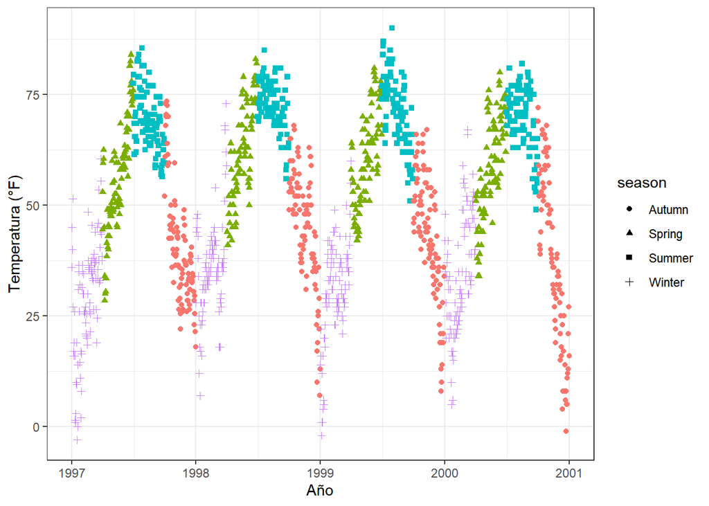

```r
ggplot(chic,
       aes(x = date, y = temp,
           color = season, shape = season)) +
  geom_point() +
  labs(x = "Año", y = "Temperatura (°F)") +
  guides(color = "none")
```

## Remover el título de la leyenda:

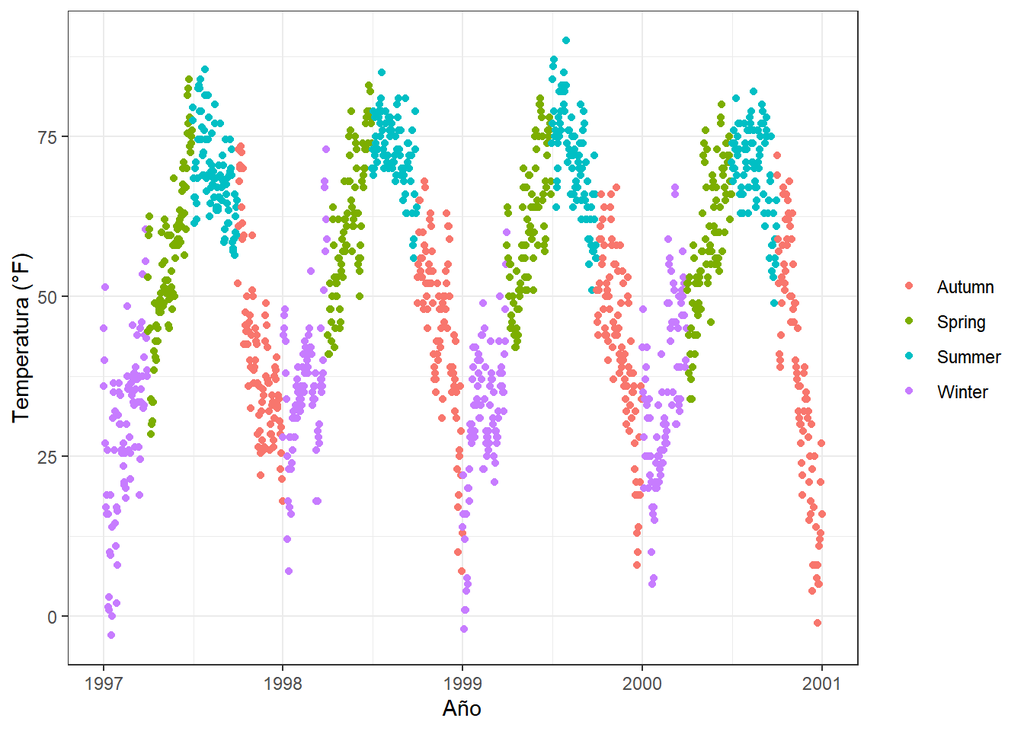

```r
ggplot(chic, aes(x = date, y = temp, color = season)) +
  geom_point() +
  labs(x = "Año", y = "Temperatura (°F)") +
  theme(legend.title = element_blank())
```

## Posición de la leyenda:

Tenemos algunas opciones:

- *top*
- *right* (este es el default)
- *bottom*
- *left*

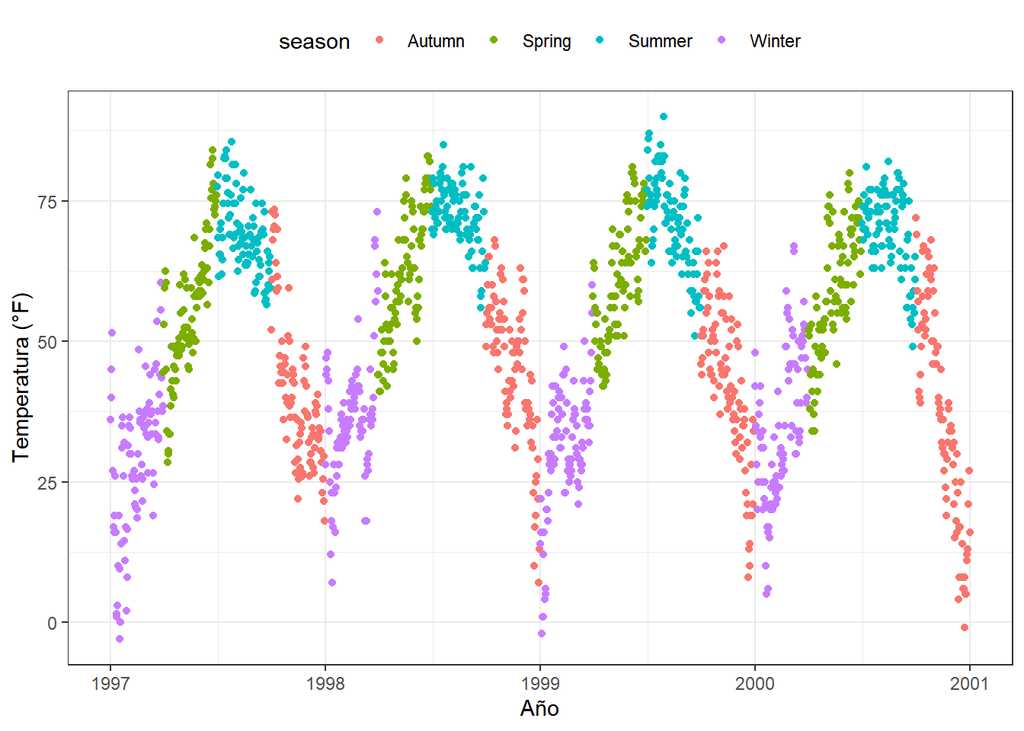

```r
ggplot(chic, aes(x = date, y = temp, color = season)) +
  geom_point() +
  labs(x = "Año", y = "Temperatura (°F)") +
  theme(legend.position = "top")
```

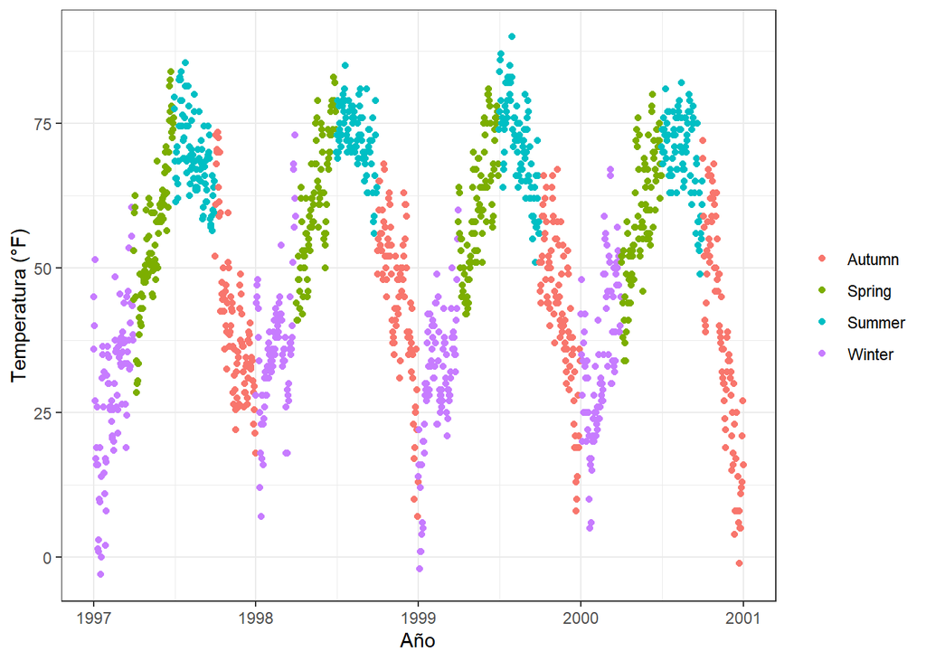

```r
ggplot(chic, aes(x = date, y = temp, color = season)) +
  geom_point() +
  labs(x = "Año", y = "Temperatura (°F)",
       color = NULL) +
  theme(legend.position.inside = c(.15, .15),
        legend.background = element_rect(fill = "transparent"))
```

## Dirección de la leyenda:

En el siguiente ejemplo dejamos la leyenda en dirección horizontal

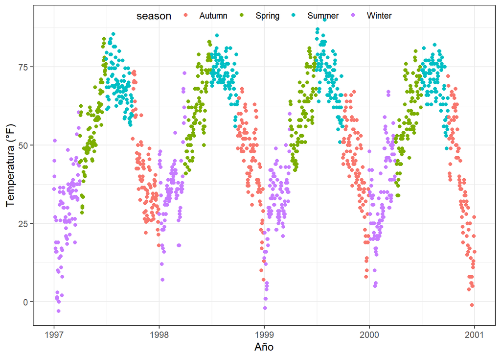

```r
ggplot(chic, aes(x = date, y = temp, color = season)) +
  geom_point() +
  labs(x = "Año", y = "Temperatura (°F)") +
  theme(legend.position = "inside",
        legend.position.inside = c(.5, .97),
        legend.direction = "horizontal",
        legend.background = element_rect(fill = "transparent"))
```

## Estilo del título de la leyenda:

Para alterar el estilo del título de la leyenda agregamos el argumento *legend.title* en *theme()*

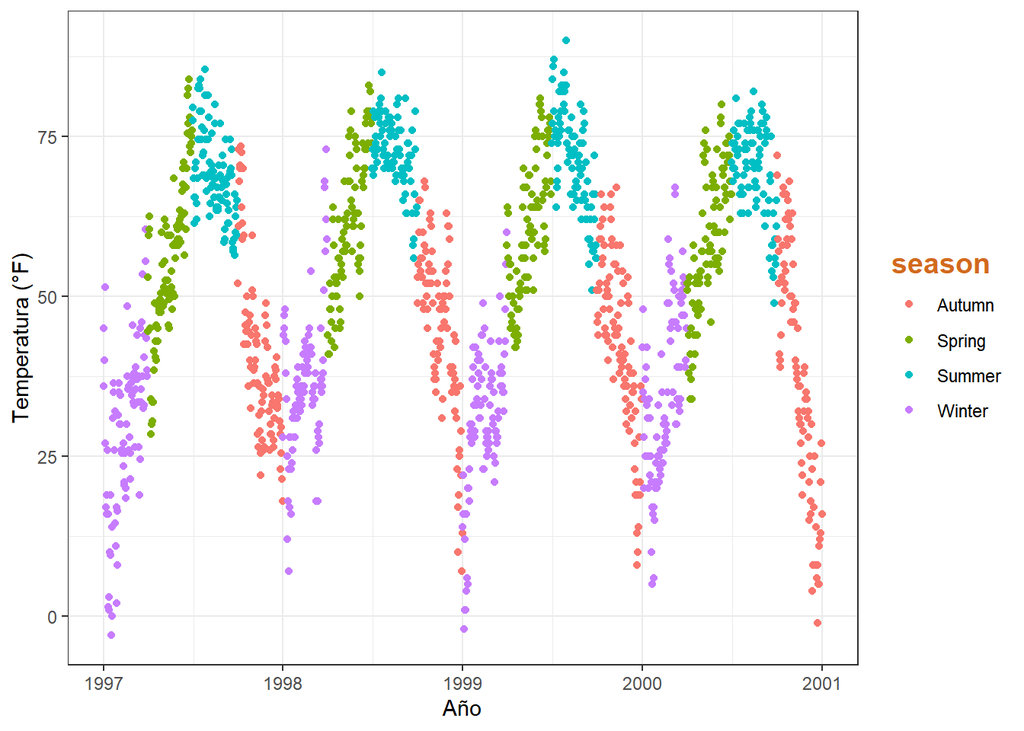

```r
# theme(legend.title = ())

ggplot(chic, aes(x = date, y = temp, color = season)) +
  geom_point() +
  labs(x = "Año", y = "Temperatura (°F)") +
  theme(legend.title = element_text(color = "chocolate",
                                    size = 14, face = "bold"))
```

Además es posible cambiar el texto del título de la leyenda

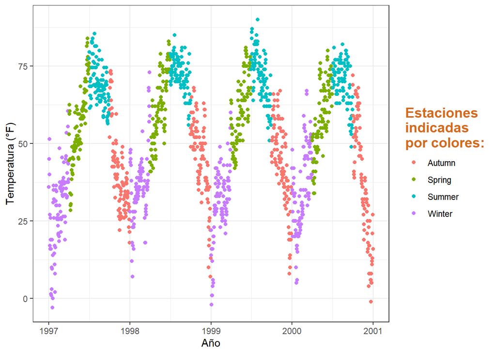

```r
ggplot(chic, aes(x = date, y = temp, color = season)) +
  geom_point() +
  labs(x = "Año", y = "Temperatura (°F)",
       color = "Estaciones\nindicadas\npor colores:") +
  theme(legend.title = element_text(color = "chocolate",
                                    size = 14, face = "bold"))
```

```r
# aquí \n es usado para quiebre de texto
```

## Alterar el orden de los ítems de la leyenda:

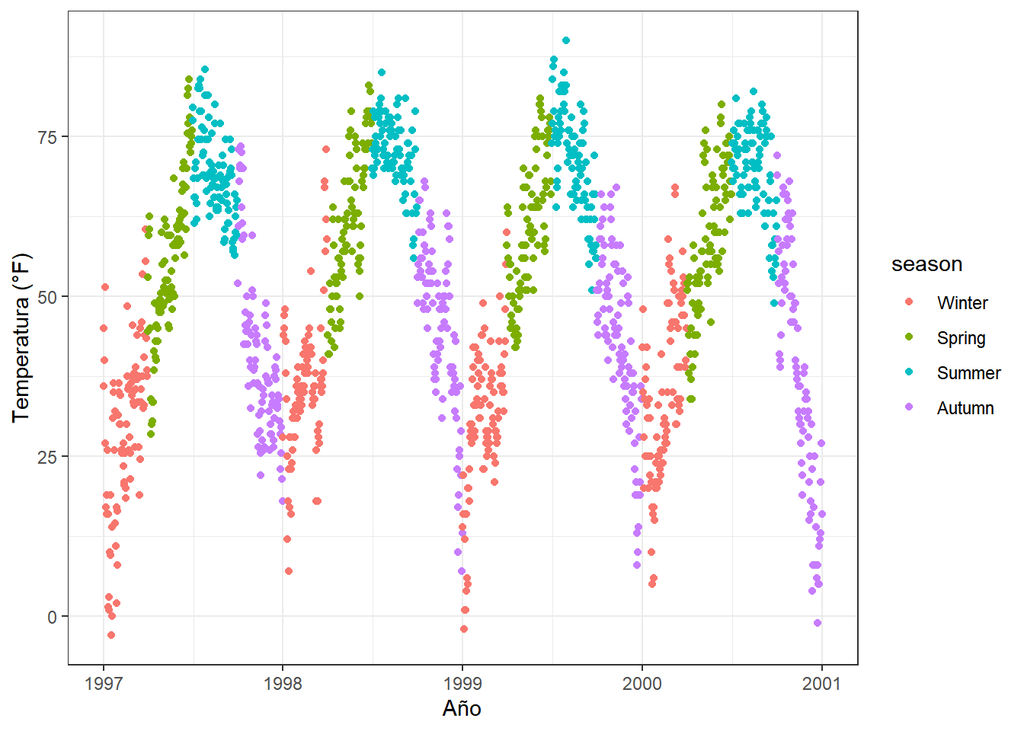

```r
# determinar el orden de los niveles antes de la graficación

chic$season <-
  factor(chic$season,
         levels = c("Winter", "Spring", "Summer", "Autumn"))


# graficar

ggplot(chic, aes(x = date, y = temp, color = season)) +
  geom_point() +
  labs(x = "Año", y = "Temperatura (°F)")
```

## Alterar los nombres de los niveles de la leyenda:

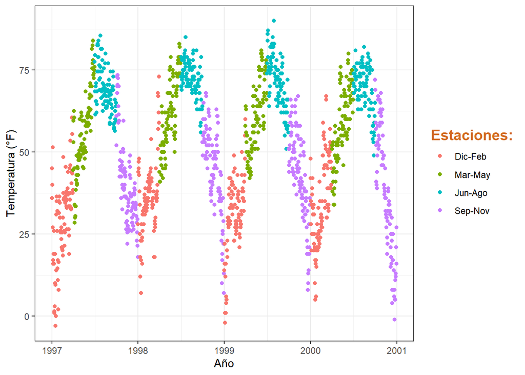

```r
# scale_color_discrete()

ggplot(chic, aes(x = date, y = temp, color = season)) +
  geom_point() +
  labs(x = "Año", y = "Temperatura (°F)") +
  scale_color_discrete(
    name = "Estaciones:",
    labels = c("Dic-Feb", "Mar-May", "Jun-Ago", "Sep-Nov" )
  ) +
  theme(legend.background = element_rect(fill = "transparent"),
        legend.title = element_text(color = "chocolate",
                                    size = 14,
                                    face = 2)
        )
```

## Alterar el relleno de los ítems de la leyenda:

Como opción estética, puede poner colores de relleno en los ítems de la leyenda

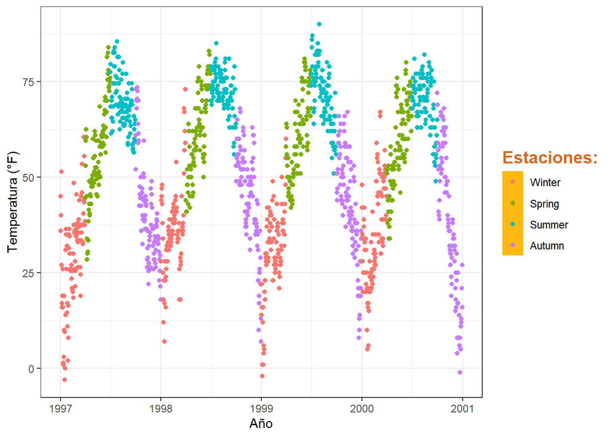

```r
# legend.key()

ggplot(chic, aes(x = date, y = temp, color = season)) +
  geom_point() +
  labs(x = "Año", y = "Temperatura (°F)") +
  theme(legend.key = element_rect(fill = "darkgoldenrod1"),
        legend.title = element_text(color = "chocolate",
                                    size = 14, face = 2)) +
  scale_color_discrete("Estaciones:")
```

O remover el relleno

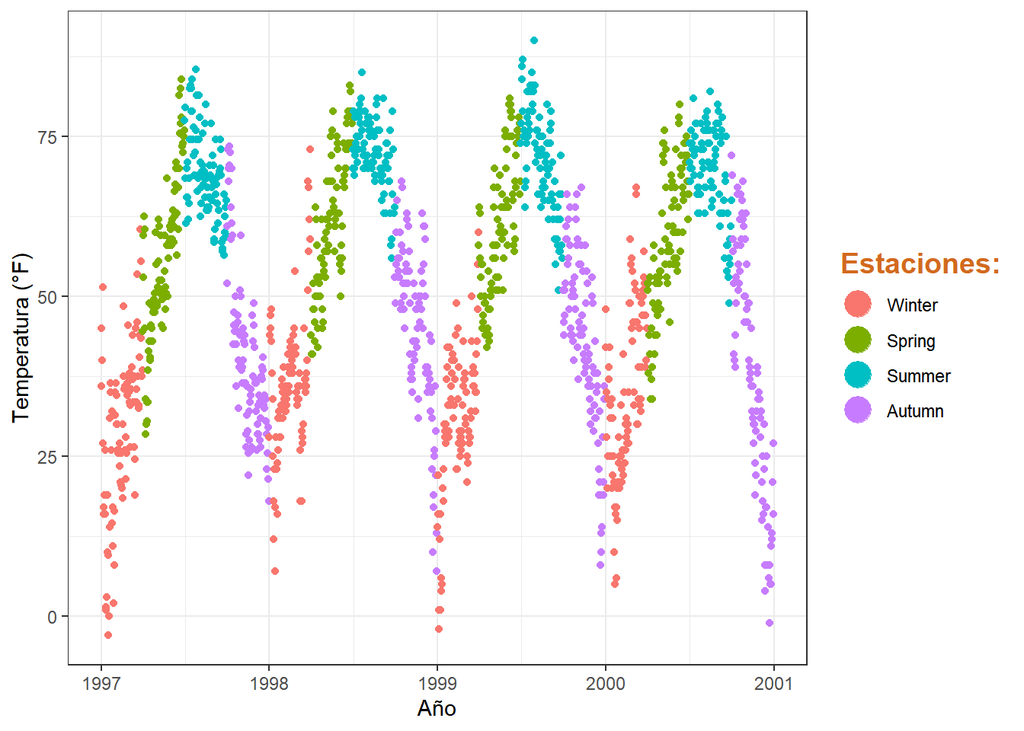

```r
# sin relleno:
# fill = NA or fill = "transparent"

# alterar el tamaño de los símbolos de la leyenda:
ggplot(chic, aes(x = date, y = temp, color = season)) +
  geom_point() +
  labs(x = "Año", y = "Temperatura (°F)") +
  theme(legend.key = element_rect(fill = NA),
        legend.title = element_text(color = "chocolate",
                                    size = 14, face = 2)) +
  scale_color_discrete("Estaciones:") +
  guides(color = guide_legend(override.aes = list(size = 6)))
```

## Otros estilos de leyenda (gradiente):

Cuando estamos mapeando una variable continua, *ggplot* por defecto determina un gradiente

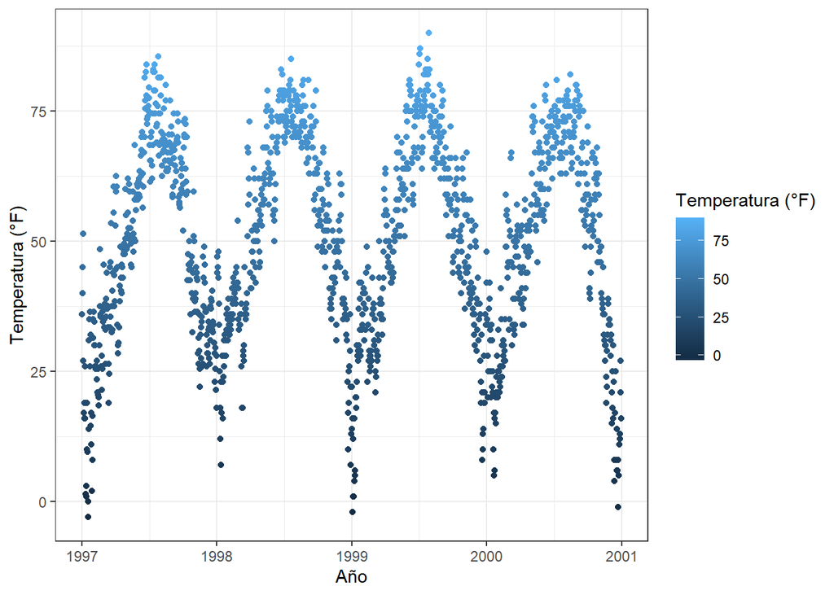

```r
ggplot(chic,
       aes(x = date, y = temp, color = temp)) +
  geom_point() +
  labs(x = "Año", y = "Temperatura (°F)", color = "Temperatura (°F)")
```

Pero podemos forzar la leyenda a mostrar valores discretos con *guide_legend()*

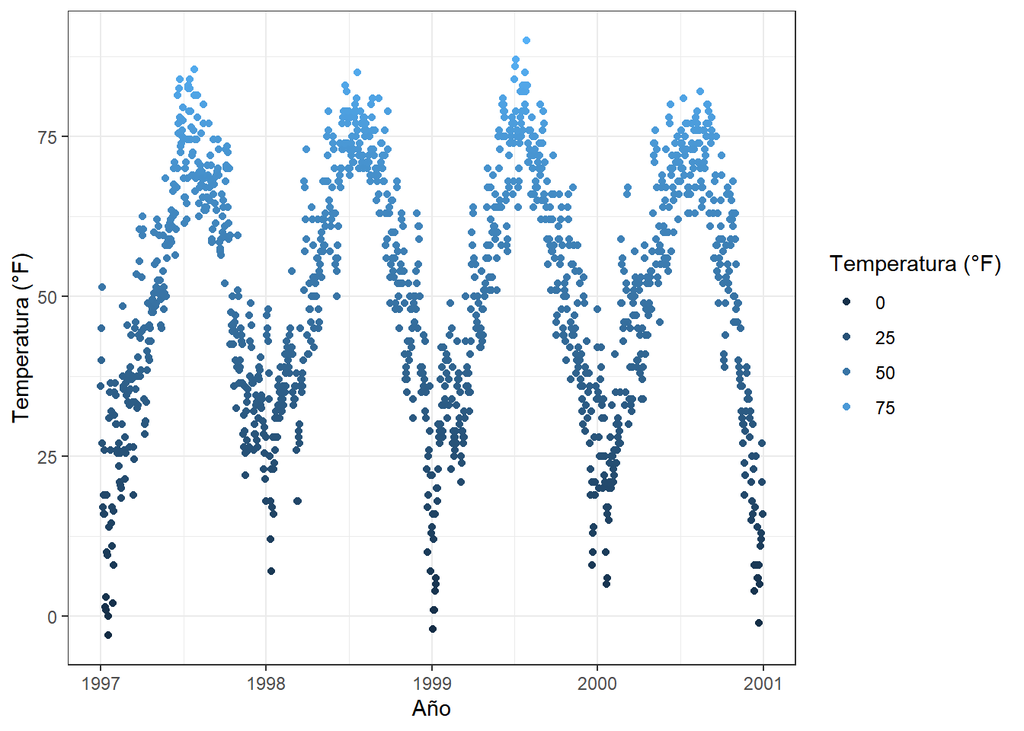

```r
ggplot(chic,
       aes(x = date, y = temp, color = temp)) +
  geom_point() +
  labs(x = "Año", y = "Temperatura (°F)", color = "Temperatura (°F)") +
  guides(color = guide_legend())
```

También podemos limitar las escalas

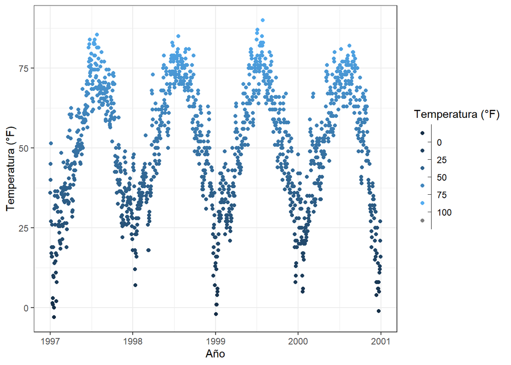

```r
ggplot(chic,
       aes(x = date, y = temp, color = temp)) +
  geom_point() +
  labs(x = "Año", y = "Temperatura (°F)", color = "Temperatura (°F)") +
  guides(color = guide_bins())
```

O utilizar una escala de colores discretas:

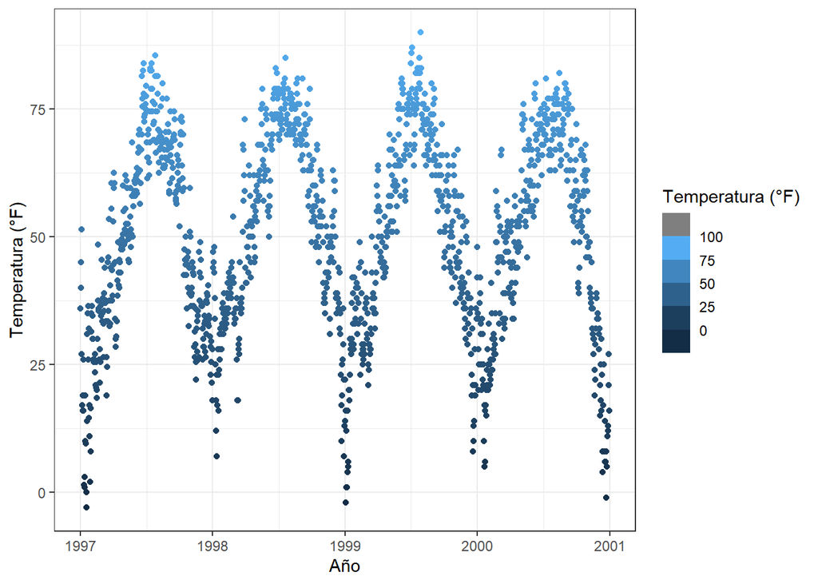

```r
ggplot(chic,
       aes(x = date, y = temp, color = temp)) +
  geom_point() +
  labs(x = "Año", y = "Temperatura (°F)", color = "Temperatura (°F)") +
  guides(color = guide_colorsteps())
```

# Fondos y líneas:

Fondos y líneas pueden ser alterados dentro de la función *theme()*

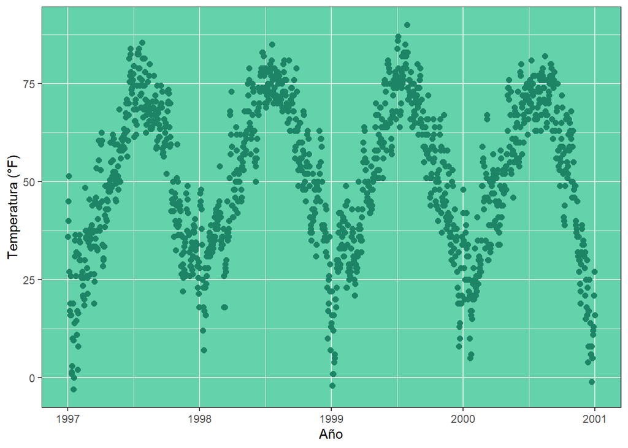

```r
ggplot(chic, aes(x = date, y = temp)) +
  geom_point(color = "#1D8565", size = 2) +
  labs(x = "Año", y = "Temperatura (°F)") +
  theme(panel.background = element_rect(
    fill = "#64D2AA", color = "#64D2AA", linewidth = 2)
  )
```

## Alterando el borde:

Observe que el color verdadero - el contorno del fondo del panel - no va a cambiar en este ejemplo, aún cuando lo hayamos especificado. Esto ocurre porque hay una capa encima de *panel.background*, o sea, *panel.border*

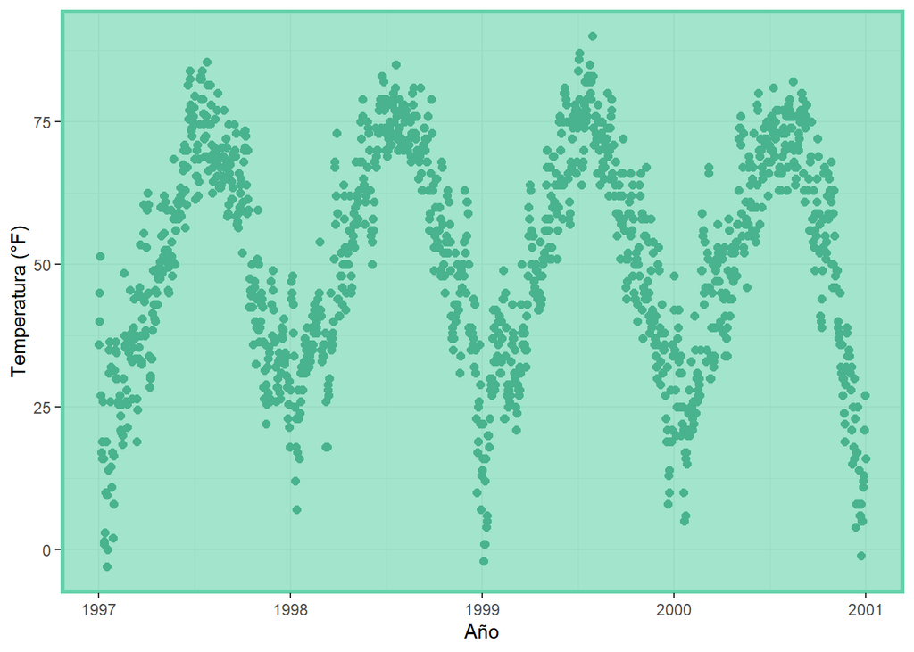

```r
ggplot(chic, aes(x = date, y = temp)) +
  geom_point(color = "#1D8565", size = 2) +
  labs(x = "Año", y = "Temperatura (°F)") +
  theme(panel.border = element_rect(
    fill = "#64D2AA99", color = "#64D2AA", size = 2)
  )
```

## Alterar líneas:

Para alterar las líneas usamos *panel.grid()* o, para cada conjunto de líneas separadamente: *panel.grid.major()* y *panel.grid.minor()*

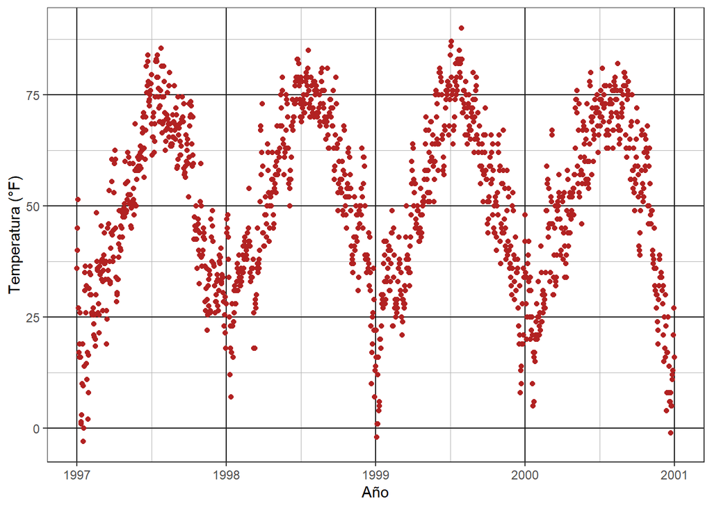

```r
ggplot(chic, aes(x = date, y = temp)) +
  geom_point(color = "firebrick") +
  labs(x = "Año", y = "Temperatura (°F)") +
  theme(panel.grid.major = element_line(color = "gray10", linewidth = .5),
        panel.grid.minor = element_line(color = "gray70", linewidth = .25))
```

Podemos también detallar más

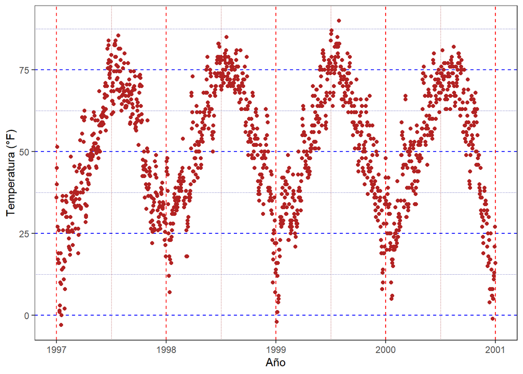

```r
ggplot(chic, aes(x = date, y = temp)) +
geom_point(color = "firebrick") +
  labs(x = "Año", y = "Temperatura (°F)") +
  theme(panel.grid.major = element_line(size = .5, linetype = "dashed"),
        panel.grid.minor = element_line(size = .25, linetype = "dotted"),
        panel.grid.major.x = element_line(color = "red1"),
        panel.grid.major.y = element_line(color = "blue1"),
        panel.grid.minor.x = element_line(color = "red4"),
        panel.grid.minor.y = element_line(color = "blue4"))
```

Podemos también remover las líneas

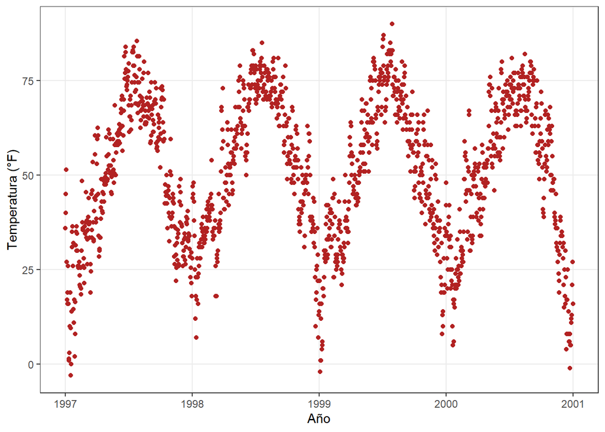

```r
ggplot(chic, aes(x = date, y = temp)) +
  geom_point(color = "firebrick") +
  labs(x = "Año", y = "Temperatura (°F)") +
  theme(panel.grid.minor = element_blank())
```

Todas las líneas

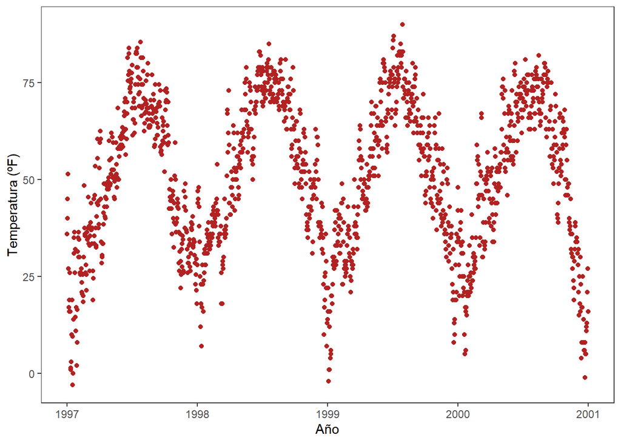

```r
ggplot(chic, aes(x = date, y = temp)) +
  geom_point(color = "firebrick") +
  labs(x = "Año", y = "Temperatura (ºF)") +
  theme(panel.grid = element_blank())
```

```r
# o theme_minimal()
```

## Alterar el color del fondo:

Podemos modificar con *panel.background()* y *plot.backgroun()*

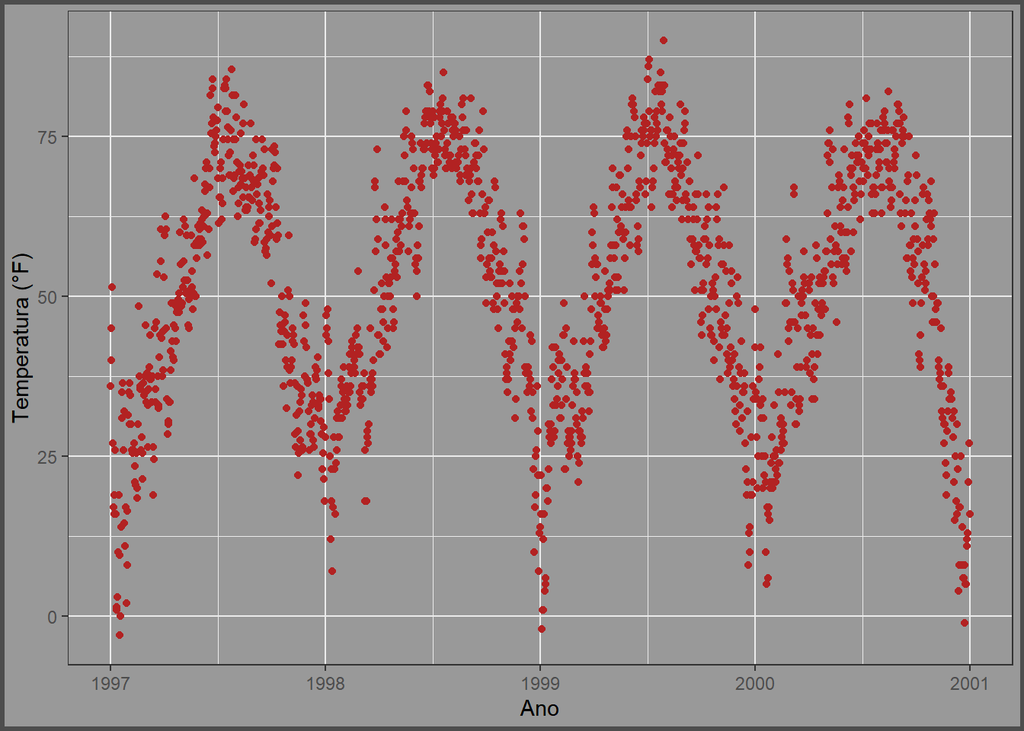

```r
ggplot(chic, aes(x = date, y = temp)) +
  geom_point(color = "firebrick") +
  labs(x = "Ano", y = "Temperatura (°F)") +
  theme(panel.background = element_rect(fill = NA),
        plot.background = element_rect(fill = "gray60",
                                       color = "gray30", size = 2))
```

Un ejemplo más

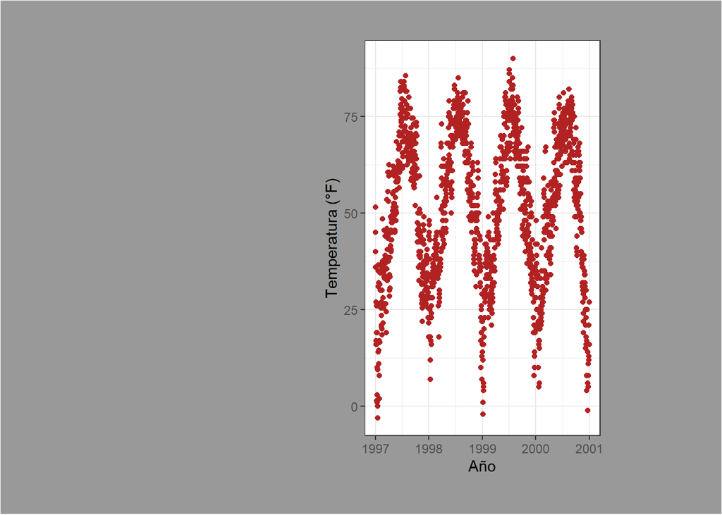

```r
ggplot(chic, aes(x = date, y = temp)) +
  geom_point(color = "firebrick") +
  labs(x = "Año", y = "Temperatura (°F)") +
  theme(plot.background = element_rect(fill = "gray60"),
        plot.margin = margin(t = 1, r = 3, b = 1, l = 8, unit = "cm"))
```

## Proximos pasos:

Ahora que conoces ggplot puedes aventurarte un poco y practicar algunos comandos con los **ejercicios** de esta etapa.

Una vez corregidos los ejercicios con la clase, trabajaremos con **gráficos interactivos**.

## Fin :)

Espero que este material haya ayudado de alguna forma y quedo a disposición para aclarar lo que sea necesario.

Dra. Fernanda Rodrigues de Avila

https://avilaf.github.io/

fernandar.avila@gmail.com